# Laboratorium 12

## Damian Guzek & Kamil Sandak

```python
#import niezbędnych pakietów
import numpy as np
import pandas as pd
import matplotlib
import matplotlib.pyplot as plt
import datetime
import seaborn as sns
from scipy import stats
import pylab
import statsmodels.api as sm

%matplotlib inline
```

## Cel pracy

Celem pracy jest zbadanie zachowania franka szwajcarskiego, polskiego złotego oraz funta sterlinga względem najbardziej popularnej europejskiej waluty.Sprawdzimy na ile stabilne i prosperujące są kursy narodowych walut tych państw.

## Opis danych

Nasze dane obejmują okres od 4 stycznia 1999 roku do 8 maja 2020 roku. Podczas tego okresu miało miejsce kilka bardzo ważnych wydarzeń dla gospodarek wyżej wymienionych krajów, takich jak Brexit, wejście Polski do Unii Europejskiej oraz kryzys gospodarczy w 2008 roku. Nasz zbiór danych zawiera kursy walut w stosunku do Euro takich jak dolar australijski, chiński yuan, rosyjski rubel, szwedzka korona i tak dalej.

## Import, podgląd oraz czyszczenie danych

```python
df = pd.read_csv("/Users/damianguzek/Desktop/daneEuro.csv")
```

```python
#podgląd końcówki danych
df.tail()
```

|  | Period\Unit: | [Australian dollar ] | [Bulgarian lev ] | [Brazilian real ] | [Canadian dollar ] | [Swiss franc ] | [Chinese yuan renminbi ] | [Cypriot pound ] | [Czech koruna ] | [Danish krone ] | ... | [Romanian leu ] | [Russian rouble ] | [Swedish krona ] | [Singapore dollar ] | [Slovenian tolar ] | [Slovak koruna ] | [Thai baht ] | [Turkish lira ] | [US dollar ] | [South African rand ] |
| --- | --- | --- | --- | --- | --- | --- | --- | --- | --- | --- | --- | --- | --- | --- | --- | --- | --- | --- | --- | --- | --- |
| 5521 | 2020-05-04 | 1.7022 | 1.9558 | 6.0781 | 1.5390 | 1.0548 | 7.7275 | NaN | 27.119 | 7.4622 | ... | 4.8368 | 82.3404 | 10.8113 | 1.5495 | NaN | NaN | 35.397 | 7.6932 | 1.0942 | 20.3924 |
| 5522 | 2020-05-05 | 1.6825 | 1.9558 | 5.9576 | 1.5201 | 1.0525 | 7.6575 | NaN | 26.978 | 7.4612 | ... | 4.8260 | 80.4713 | 10.6980 | 1.5359 | NaN | NaN | 35.126 | 7.6866 | 1.0843 | 19.9018 |
| 5523 | 2020-05-06 | 1.7046 | 1.9558 | 6.0896 | 1.5225 | 1.0530 | 7.6707 | NaN | 26.987 | 7.4618 | ... | 4.8233 | 80.7789 | 10.6278 | 1.5335 | NaN | NaN | 35.004 | 7.7178 | 1.0807 | 20.0603 |
| 5524 | 2020-05-07 | 1.6704 | 1.9558 | 6.2271 | 1.5177 | 1.0530 | 7.6427 | NaN | 27.158 | 7.4605 | ... | 4.8235 | 79.5801 | 10.6200 | 1.5303 | NaN | NaN | 34.969 | 7.7792 | 1.0783 | 20.0698 |
| 5525 | 2020-05-08 | 1.6613 | 1.9558 | 6.3074 | 1.5118 | 1.0529 | 7.6719 | NaN | 27.251 | 7.4598 | ... | 4.8280 | 79.8383 | 10.5875 | 1.5326 | NaN | NaN | 34.958 | 7.7252 | 1.0843 | 19.9970 |

5 rows × 41 columns

```python
#podgląd początku danych
df.head()
```

|  | Period\Unit: | [Australian dollar ] | [Bulgarian lev ] | [Brazilian real ] | [Canadian dollar ] | [Swiss franc ] | [Chinese yuan renminbi ] | [Cypriot pound ] | [Czech koruna ] | [Danish krone ] | ... | [Romanian leu ] | [Russian rouble ] | [Swedish krona ] | [Singapore dollar ] | [Slovenian tolar ] | [Slovak koruna ] | [Thai baht ] | [Turkish lira ] | [US dollar ] | [South African rand ] |
| --- | --- | --- | --- | --- | --- | --- | --- | --- | --- | --- | --- | --- | --- | --- | --- | --- | --- | --- | --- | --- | --- |
| 0 | 1999-01-04 | 1.9100 | NaN | NaN | 1.8004 | 1.6168 | NaN | 0.58231 | 35.107 | 7.4501 | ... | 1.3111 | 25.2875 | 9.4696 | 1.9554 | 189.045 | 42.991 | 42.6799 | 0.3723 | 1.1789 | 6.9358 |
| 1 | 1999-01-05 | 1.8944 | NaN | NaN | 1.7965 | 1.6123 | NaN | 0.58230 | 34.917 | 7.4495 | ... | 1.3168 | 26.5876 | 9.4025 | 1.9655 | 188.775 | 42.848 | 42.5048 | 0.3728 | 1.1790 | 6.7975 |
| 2 | 1999-01-06 | 1.8820 | NaN | NaN | 1.7711 | 1.6116 | NaN | 0.58200 | 34.850 | 7.4452 | ... | 1.3168 | 27.4315 | 9.3050 | 1.9699 | 188.700 | 42.778 | 42.6949 | 0.3722 | 1.1743 | 6.7307 |
| 3 | 1999-01-07 | 1.8474 | NaN | NaN | 1.7602 | 1.6165 | NaN | 0.58187 | 34.886 | 7.4431 | ... | 1.3092 | 26.9876 | 9.1800 | 1.9436 | 188.800 | 42.765 | 42.1678 | 0.3701 | 1.1632 | 6.8283 |
| 4 | 1999-01-08 | 1.8406 | NaN | NaN | 1.7643 | 1.6138 | NaN | 0.58187 | 34.938 | 7.4433 | ... | 1.3143 | 27.2075 | 9.1650 | 1.9537 | 188.840 | 42.560 | 42.5590 | 0.3718 | 1.1659 | 6.7855 |

5 rows × 41 columns

```python
# Wyciągamy nasze dane
dane = df[["[Polish zloty ]","[Swiss franc ]","[UK pound sterling ]"]]
zloty = df["[Polish zloty ]"]
frank = df["[Swiss franc ]"]
funt  = df["[UK pound sterling ]"]
daty = df.iloc[0:len(funt),0]

dane.insert(0,"Data",daty,True)
dane.columns = ["data","zloty","frank","funt"]
```

```python
#sprawdzamy czy brakuje nam jakiś danych
print("Czy brakuje nam danych w PLN?   ",pd.isnull(zloty).values.any())
print("Czy brakuje nam danych w CHF?   ",pd.isnull(frank).values.any())
print("Czy brakuje nam danych w GBP?   ",pd.isnull(funt).values.any())
```

```
Czy brakuje nam danych w PLN?    True
Czy brakuje nam danych w CHF?    True
Czy brakuje nam danych w GBP?    True
```

```python
#jak widac występują NaN'y nieliczne - trzeba uzupełnić najbardziej odpowiednią wartością
print(dane.isna().sum())
dane=dane.fillna(method="bfill")
```

```
data      0
zloty    62
frank    62
funt     62
dtype: int64
```

```python
#Po wyczyszczeniu dodajemy dodaktowe zmienne potrzebne do analizy sezonowości i trendu
dane = dane.set_index(dane["data"])
dane["rok"] = pd.DatetimeIndex(dane["data"]).year
dane["miesiac"] = pd.DatetimeIndex(dane["data"]).month
dane["dzien"] = pd.DatetimeIndex(dane["data"]).dayofweek

dane
```

| data | data | zloty | frank | funt | rok | miesiac | dzien |
| --- | --- | --- | --- | --- | --- | --- | --- |
| 1999-01-04 | 1999-01-04 | 4.0712 | 1.6168 | 0.71110 | 1999 | 1 | 0 |
| 1999-01-05 | 1999-01-05 | 4.0245 | 1.6123 | 0.71220 | 1999 | 1 | 1 |
| 1999-01-06 | 1999-01-06 | 4.0065 | 1.6116 | 0.70760 | 1999 | 1 | 2 |
| 1999-01-07 | 1999-01-07 | 4.0165 | 1.6165 | 0.70585 | 1999 | 1 | 3 |
| 1999-01-08 | 1999-01-08 | 4.0363 | 1.6138 | 0.70940 | 1999 | 1 | 4 |
| ... | ... | ... | ... | ... | ... | ... | ... |
| 2020-05-04 | 2020-05-04 | 4.5668 | 1.0548 | 0.87898 | 2020 | 5 | 0 |
| 2020-05-05 | 2020-05-05 | 4.5316 | 1.0525 | 0.87060 | 2020 | 5 | 1 |
| 2020-05-06 | 2020-05-06 | 4.5394 | 1.0530 | 0.87253 | 2020 | 5 | 2 |
| 2020-05-07 | 2020-05-07 | 4.5467 | 1.0530 | 0.87478 | 2020 | 5 | 3 |
| 2020-05-08 | 2020-05-08 | 4.5482 | 1.0529 | 0.87535 | 2020 | 5 | 4 |

5526 rows × 7 columns

## Wstępna analiza

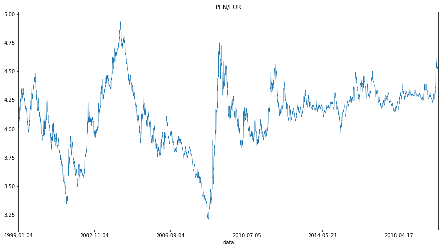

```python
plt.figure(figsize=(15,8))
dane['zloty'].plot(linewidth=0.5)
plt.title("PLN/EUR")
```

Złotówka wydaje się trzymać trend na równym poziomie, jednak ze sporymi wariancjami długoterminowymi i małymi krótkoterminowymi

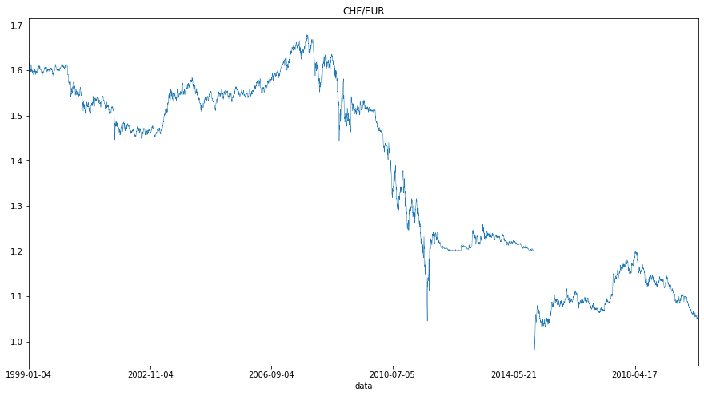

```python
plt.figure(figsize=(15,8))
dane['frank'].plot(linewidth=0.5)
plt.title("CHF/EUR")
```

Kurs CHF zdaje się być najstabilnieszą z walut. (O najmniejszej wariancji) za to z widoczym trendem spatkowym

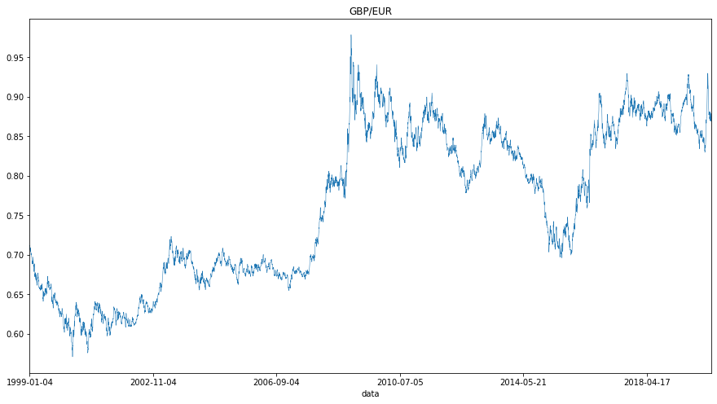

```python
plt.figure(figsize=(15,8))
dane['funt'].plot(linewidth=0.5)
plt.title("GBP/EUR")
```

Funt wygląda na nabardziej niestabliną z omawianych walut

## Badanie sezonowości

### PLN

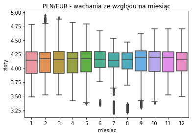

```python
sns.boxplot(y='zloty',x='miesiac', data=dane)
plt.title("PLN/EUR - wachania ze względu na miesiąc")
```

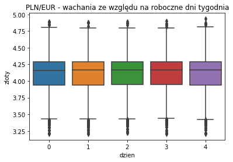

```python
sns.boxplot(y='zloty',x='dzien', data=dane)
plt.title("PLN/EUR - wachania ze względu na roboczne dni tygodnia")
```

W przypadku złotówki występuje coś bardzo ciekawego. Występuje sezonowość w okresie letnim. Jednak dzień tygodnia nie ma wpływu na kurs złotówki

### CHF

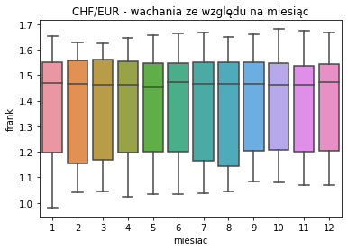

```python
sns.boxplot(y='frank',x='miesiac', data=dane)
plt.title("CHF/EUR - wachania ze względu na miesiąc")
```

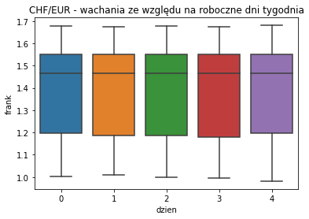

```python
sns.boxplot(y='frank',x='dzien', data=dane)
plt.title("CHF/EUR - wachania ze względu na roboczne dni tygodnia")
```

Frank szwajcarski wykazuje typową tendecję braku sezonowości, które są typowe dla najmocniejszych światowych walut

### GBP

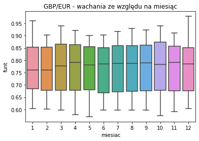

```python
sns.boxplot(y='funt',x='miesiac', data=dane)
plt.title("GBP/EUR - wachania ze względu na miesiąc")
```

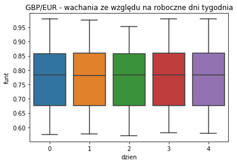

```python
sns.boxplot(y='funt',x='dzien', data=dane)
plt.title("GBP/EUR - wachania ze względu na roboczne dni tygodnia")
```

Funt brytyjski również wykazuje małą sezonowość wariancji, tutaj jednak w okresie zimowym. Sezonowość nie występuje ze względu na dzień tygodnia

## Trend

W tej części analizy zastosujemy średnią ruchomą o parametrze 100 do wygładzenia naszych danych i znalezienia trednu. Sprawdzimy równieść trend w ujęciu wariancji i średnich rocznych.

### PLN

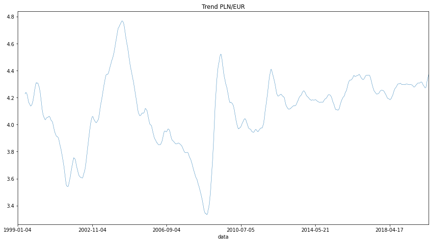

```python
plt.figure(figsize=(15,8))
dane.iloc[:,1].rolling(window=100).mean().plot(linewidth=0.5)
plt.title("Trend PLN/EUR")
```

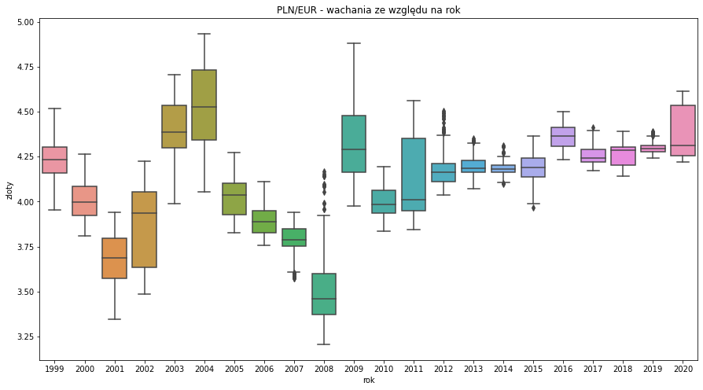

```python
plt.figure(figsize=(15,8))
sns.boxplot(y='zloty',x='rok', data=dane)
plt.title("PLN/EUR - wachania ze względu na rok")
```

Na wykresie łatwo zauważyć że w pobliżu ważnych wydarzeń historycznych takich jak wstąpienie Polski do Unii Europejskiej (2004), światowy kryzys (2008), epidemia korona wirusa (2020) wariancja złotówki narasta. Warto również zwrócić uwagę na sukcesywny wzrost wartości PLN w stosunku do euro od 2004 do 2008 roku.